# 04_supplementary

## Supplementary analyses

```python
import pandas as pd
import seaborn as sns
from matplotlib import pyplot as plt
import numpy as np
from scripts.utils import concat_dfs
import itertools
```

- Imports and preprocessing
- Some examples of association chains
- Jump size dynamics
- Jump distributions for some sample trials
- Visualize trials in vector space
- Visualize number of dead-ends by diversity level

### Imports and preprocessing

```python
PATH = 'animal_game/analyses/21_08_20'
LOG_PATH = 'animal_game/logs/21_08_20'
MODEL_PATH = 'animal_game/models/21_08_20'
```

```python
data = pd.read_csv(f'{PATH}/processed.tsv.gz',
                   sep='\t', compression='gzip')
aggs = pd.read_csv(f'{PATH}/aggregates.tsv', sep='\t')
```

```python
data.rename({'noise_level_a0': 'diversity_level'}, axis=1, inplace=True)
aggs.rename({'noise_level_a0': 'diversity_level'}, axis=1, inplace=True)
```

```python
all_data = data.copy()
all_aggs = aggs.copy()
aggs = aggs[aggs['diversity_level']<=14]
data = data[data['diversity_level']<=14]
```

```python
data['diversity_dodge'] = data['diversity_level'] + \
                          np.random.uniform(-.2,.2,size=data.shape[0])
aggs['diversity_dodge'] = aggs['diversity_level'] + \
                          np.random.uniform(-.2,.2,size=aggs.shape[0])
```

```python
data['best_agent'] = np.where(data['performance_a0']==data['performance_best'],
                              data['agent_0'],
                              data['agent_1'])
```

### Some examples of association chains

Below, some association chains for randomly sampled trials, at all diversity levels, with seed word "goat".

```python
seed = 'goat'
for didx, dl in enumerate(range(0,15)):
    subdata = data[(data['diversity_level']==dl) &\
                   (data['init_seed']=='goat')]
    print(f'\033[1m\033[34mNoise level: {dl}\033[0m')
    sampled = subdata.sample(n=1, random_state=0)
    pairs = sampled.pair.tolist()
    a0s = sampled.agent_0.tolist()
    a1s = sampled.agent_1.tolist()
    for idx, (p, a0, a1) in enumerate(list(zip(pairs, a0s, a1s))):
        pair = p +'_2_0.01179.txt'
        agent0 = a0 +'_1_0.01179.txt'
        a0df = pd.read_csv(f'{LOG_PATH}/individual/{agent0}')
        a0df = a0df[a0df['init_seed']==seed].response.tolist()
        agent1 = a1 +'_1_0.01179.txt'
        a1df = pd.read_csv(f'{LOG_PATH}/individual/{agent1}')
        a1df = a1df[a1df['init_seed']==seed].response.tolist()
        pdf = pd.read_csv(f'{LOG_PATH}/pairs/{pair}')
        plist = pdf[pdf['init_seed']==seed].response.tolist()
        print('\033[1mAgent 0\033[0m: ' + f'\033[1m\033[31m{seed}\033[0m, ' + ', '.join(a0df)+ '\n')
        print('\033[1mAgent 1\033[0m: ' + f'\033[1m\033[31m{seed}\033[0m, ' + ', '.join(a1df)+ '\n')
        print('\033[1mPair\033[0m: ' + f'\033[1m\033[31m{seed}\033[0m, ' + ', '.join(plist) + '\n\n')
```

```
Noise level: 0
Agent 0: goat, cow, pig, chicken, duck, goose, pheasant, deer, elk, antelope, bison, black_bear, grizzly_bear, polar_bear, killer_whale, sperm_whale, blue_whale, fin_whale, whale, dolphin, shark, squid, cuttlefish, sawfish, sea_snake, coral_snake, diamondback_rattlesnake, cottonmouth, copperhead, ra…

Agent 1: goat, cow, pig, chicken, duck, goose, pheasant, deer, elk, antelope, bison, black_bear, grizzly_bear, polar_bear, killer_whale, sperm_whale, blue_whale, fin_whale, whale, dolphin, shark, squid, cuttlefish, sawfish, sea_snake, coral_snake, diamondback_rattlesnake, cottonmouth, copperhead, ra…

Pair: goat, cow, pig, chicken, duck, goose, pheasant, deer, elk, antelope, bison, black_bear, grizzly_bear, polar_bear, killer_whale, sperm_whale, blue_whale, fin_whale, whale, dolphin, shark, squid, cuttlefish, sawfish, sea_snake, coral_snake, diamondback_rattlesnake, cottonmouth, copperhead, rattl…


Noise level: 1
Agent 0: goat, pig, cow, chicken, duck, goose, pheasant, deer, elk, antelope, bison, black_bear, grizzly_bear, polar_bear, blue_whale, killer_whale, sperm_whale, fin_whale, whale, dolphin, shark, cuttlefish, squid, sawfish, coral_snake, sea_snake, diamondback_rattlesnake, cottonmouth, copperhead, ra…

Agent 1: goat, cow, pig, sheep, reindeer, polar_bear, grizzly_bear, black_bear, tapir, caiman, sea_snake, coral_snake, sawfish, squid, cuttlefish, octopus, shark, dolphin, whale, killer_whale, sperm_whale, blue_whale, fin_whale, sea_lion, sea_cow, millipede, harvestman, cockroach, tarantula, scorpio…

Pair: goat, pig, cow, chicken, duck, goose, pheasant, deer, elk, antelope, bison, black_bear, grizzly_bear, polar_bear, fin_whale, sperm_whale, blue_whale, killer_whale, whale, dolphin, shark, cuttlefish, squid, sawfish, coral_snake, sea_snake, diamondback_rattlesnake, cottonmouth, copperhead, rattl…


Noise level: 2
Agent 0: goat, sheep, cow, chicken, reindeer, grizzly_bear, polar_bear, black_bear, tapir, caiman, sea_snake, coral_snake, sawfish, squid, cuttlefish, octopus, shark, whale, fin_whale, sperm_whale, dolphin, killer_whale, blue_whale, sea_lion, sea_cow, millipede, harvestman, cockroach, tarantula, sco…

Agent 1: goat, chicken, pig, sheep, cow, reindeer, grizzly_bear, polar_bear, black_bear, tapir, caiman, sea_snake, coral_snake, sawfish, squid, cuttlefish, octopus, shark, blue_whale, fin_whale, dolphin, sperm_whale, killer_whale, whale, sea_lion, sea_cow, millipede, harvestman, cockroach, tarantula…

Pair: goat, sheep, pig, duck, goose, pheasant, deer, elk, antelope, bison, black_bear, polar_bear, grizzly_bear, blue_whale, fin_whale, sperm_whale, killer_whale, dolphin, whale, shark, cuttlefish, squid, sawfish, coral_snake, sea_snake, diamondback_rattlesnake, cottonmouth, copperhead, snake, lizar…


Noise level: 3
Agent 0: goat, cat, chicken, dachshund, cow, duck, goose, pheasant, beaver, antelope, deer, bison, polar_bear, black_bear, grizzly_bear, sperm_whale, blue_whale, killer_whale, whale, dolphin, fin_whale, shark, starfish, prawn, sawfish, coral_snake, snake, sea_snake, copperhead, cottonmouth, diamondb…

Agent 1: goat, sheep, rabbit, cat, cow, reindeer, grizzly_bear, black_bear, polar_bear, tapir, caiman, sea_snake, rattlesnake, sawfish, crab, starfish, squid, shark, dolphin, sperm_whale, fin_whale, killer_whale, whale, blue_whale, sea_lion, sea_cow, millipede, harvestman, cockroach, scorpion, taran…

Pair: goat, cat, rabbit, mouse, poodle, dog, dachshund, chicken, pekingese, pig, hamster, guinea_pig, hyena, chimpanzee, baboon, polecat, weasel, rat, sheep, monkey, lion, rhinoceros, leopard, tiger, panther, tarantula, scorpion, rattlesnake, sea_snake, snake, toad, lizard, diamondback_rattlesnake, …


Noise level: 4
Agent 0: goat, dog, elephant, cat, sheep, duck, goose, pheasant, beaver, antelope, deer, grizzly_bear, tapir, killer_whale, cuttlefish, polar_bear, black_bear, sperm_whale, blue_whale, crocodile, sea_lion, sea_cow, starfish, sawfish, diamondback_rattlesnake, fin_whale, rattlesnake, coral_snake, copp…

Agent 1: goat, mouse, bonobo, pig, duck, goose, pheasant, elk, antelope, beaver, tapir, polar_bear, bison, octopus, fin_whale, sea_cow, trout, grizzly_bear, alligator, whale, sea_lion, coral_snake, lobster, shrimp, gecko, diamondback_rattlesnake, frog, copperhead, cottonmouth, snake, sawfish, turtle…

Pair: goat, dog, pekingese, dachshund, monkey, gorilla, zebra, okapi, hyena, lion, rhinoceros, tiger, leopard, cow, chicken, coyote, rat, squirrel, polecat, bonobo, mouse, rabbit, elephant, cat, parakeet, parrot, pheasant, beaver, antelope, deer, otter, elk, reindeer, cuttlefish, blue_whale, sperm_w…


```

[output cut: 63 more lines]

```

Noise level: 13
Agent 0: goat, rhinoceros, beaver, copperhead, rabbit, camel, robin, donkey, mink, bumblebee, zebra, cottonmouth, chameleon, hawk, cow, aphid, hamster, turkey, snail, tapir, marmot, lemming, swift, porcupine, nymph, moose, polecat, dachshund, boa, llama, scallop, iguana, saurian, python, butterfly, …

Agent 1: goat, puma, jellyfish, gibbon, salamander, snail, salmon, tortoise, stingray, goldfish, toucan, caiman, mongoose, skunk, blue_whale, mallard, antelope, toad, zebra, panda, pigeon, flea, buffalo, marmot, dragonfly, starfish, centipede, lizard, hamster, kangaroo, bullock, armadillo, tiger, ga…

Pair: goat, rhinoceros, tortoise, rabbit, grizzly_bear, halibut, wasp, platypus, pelican, trout, parrot, spider, otter, gazelle, jellyfish, nymph, eagle, gull, baboon, crocodile, lynx, catfish, squid, dolphin, deer, moose, dingo, finch, snail, tapir, porcupine, fly, salmon, frogspawn, beetle, haddoc…


Noise level: 14
Agent 0: goat, armadillo, rooster, sperm_whale, mandril, llama, cottonmouth, millipede, trout, eagle, gerbil, tapir, catfish, ladybug, frog, pekingese, hyena, pig, piranha, killer_whale, bison, bumblebee, gorilla, sparrow, chimpanzee, vulture, wolf, elephant, rhinoceros, diamondback_rattlesnake, sil…

Agent 1: goat, catfish, platypus, gazelle, polar_bear, turkey, bear, hawk, toucan, butterfly, harvestman, seal, poodle, lynx, koala, sea_lion, polecat, duck, rooster, dragonfly, albatross, deer, chameleon, flamingo, sperm_whale, parakeet, robin, nymph, hedgehog, sidewinder, moth, wolf, dolphin, womb…

Pair: goat, armadillo, blindworm
```

## Jump size dynamics

The plots below show the jumps size dynamics for a few, randomly sampled trials, with "goat" as seed word.

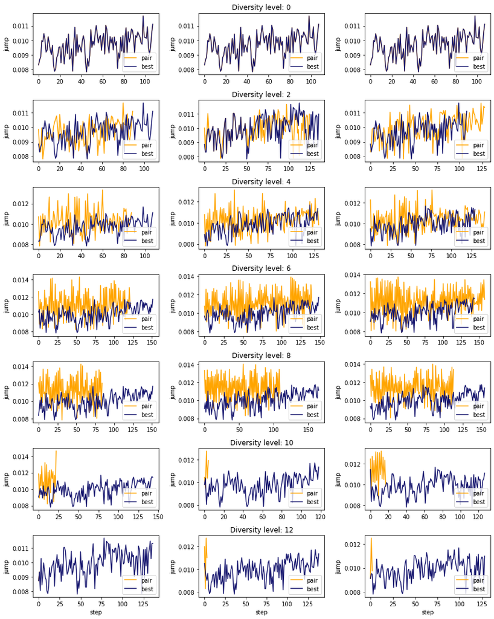

```python
levels = list(range(0,13,2))
n_sampled = 3

fig, ax = plt.subplots(nrows=len(levels),
                       ncols=n_sampled,
                       figsize=(12,15))

for dlidx, dl in enumerate(levels):
    subdata = data[(data['diversity_level']==dl) &\
                   (data['init_seed']=='goat')]
    sampled = subdata[['pair',
                       'amount_gain',
                       'best_agent',
                       'init_seed']].sample(n=n_sampled).sort_values('amount_gain')
    pairs = sampled.pair.tolist()
    best_agents = sampled.best_agent.tolist()
    for idx, (pair, best) in enumerate(list(zip(pairs,
                                                best_agents))):
        pair_id = pair +'_2_0.01179.txt'
        agent = best +'_1_0.01179.txt'
        if best == subdata['agent_0'].iloc[0]:
            target_probs = 'prob0'
        else:
            target_probs = 'prob1'

        pdf = pd.read_csv(f'{LOG_PATH}/pairs/{pair_id}')
        pdf = pdf[pdf['init_seed']==seed]
        idf = pd.read_csv(f'{LOG_PATH}/individual/{agent}')
        idf = idf[idf['init_seed']==seed]

        sns.lineplot(data=pdf.reset_index(),
                     y=target_probs,
                     x=range(pdf.shape[0]),
                     label='pair',
                     ax=ax[(dlidx, idx)],
                     color='orange')

        sns.lineplot(data=idf.reset_index(),
                     y='prob0',
                     x=range(idf.shape[0]),
                     label='best',
                     ax=ax[(dlidx, idx)],
                     color='midnightblue')

        ax[(dlidx, idx)].set_ylabel('jump')
        ax[(dlidx, idx)].legend(loc='lower right')

        if idx == 1:
            ax[(dlidx, idx)].set_title(f'Diversity level: {dl}',
                                       y=1.002)
        if dlidx == 6:
            ax[(dlidx, idx)].set_xlabel('step')

plt.tight_layout()
plt.show()
```

## Jump distributions for some sample trials

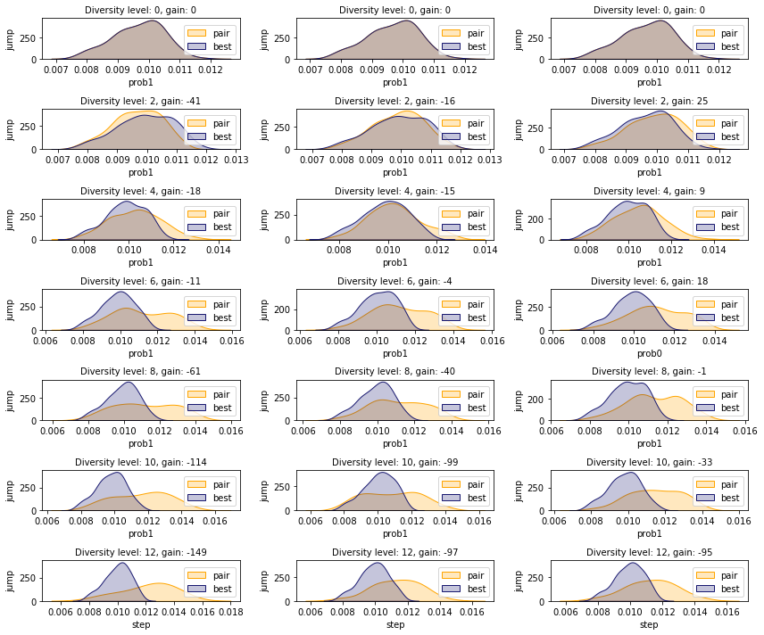

```python
fig, ax = plt.subplots(nrows=len(levels),
                       ncols=n_sampled,
                       figsize=(12,10))

for dlidx, dl in enumerate(levels):
    subdata = data[(data['diversity_level']==dl) &\
                   (data['init_seed']=='goat')]
    sampled = subdata[['pair',
                       'amount_gain',
                       'best_agent',
                       'init_seed']].sample(n=n_sampled).sort_values('amount_gain')
    pairs = sampled.pair.tolist()
    best_agents = sampled.best_agent.tolist()
    gains = sampled.amount_gain.tolist()
    for idx, (pair, best, gain) in enumerate(list(zip(pairs,
                                                      best_agents,
                                                      gains))):
        pair_id = pair +'_2_0.01179.txt'
        agent = best +'_1_0.01179.txt'
        if best == subdata['agent_0'].iloc[0]:
            target_probs = 'prob0'
        else:
            target_probs = 'prob1'

        pdf = pd.read_csv(f'{LOG_PATH}/pairs/{pair_id}')
        pdf = pdf[pdf['init_seed']==seed]
        idf = pd.read_csv(f'{LOG_PATH}/individual/{agent}')
        idf = idf[idf['init_seed']==seed]

        sns.kdeplot(data=pdf.reset_index(),
                    x=target_probs,
                    label='pair',
                    ax=ax[(dlidx, idx)],
                    color='orange',
                    fill=True)

        sns.kdeplot(data=idf.reset_index(),
                     x='prob0',
                     label='best',
                     ax=ax[(dlidx, idx)],
                     color='midnightblue',
                     fill=True)

        ax[(dlidx, idx)].set_ylabel('jump')
        ax[(dlidx, idx)].legend(loc='lower right')
        ax[(dlidx, idx)].set_title(f'Diversity level: {dl}, gain: {gain}',
                                   fontsize=10)
        if dlidx == 6:
            ax[(dlidx, idx)].set_xlabel('step')

plt.tight_layout()
plt.show()
```

## Visualize trials in vector space

Here we visualize some trials in a UMAP-reduced 2d version of agents' vector space.  
Some of these visualizations can be taken as examples of:

- Cases where doing the game in pairs avoids getting stuck in local minima = highly peripheral neighborhoods where no jump is possible within threshold;
- Cases where doing the game in pairs hinders exploring more isolated neighborhoods;
- How the dynamics of the game changes as diversity increases, with higher jumps and more exploration taking place (sometimes positively, sometimes negatively related to performance)

```python
import umap.umap_ as umap
from sklearn.preprocessing import StandardScaler
reducer = umap.UMAP(n_neighbors=5, min_dist=0.1)
```

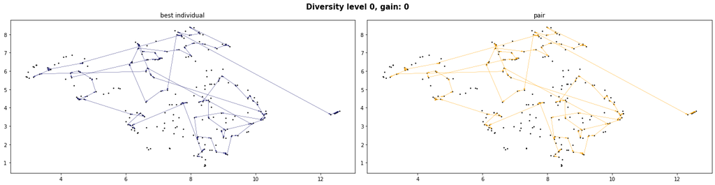

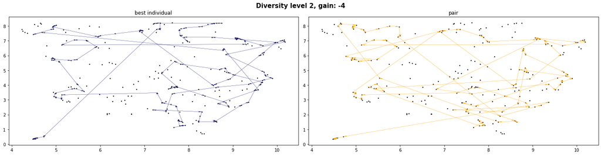

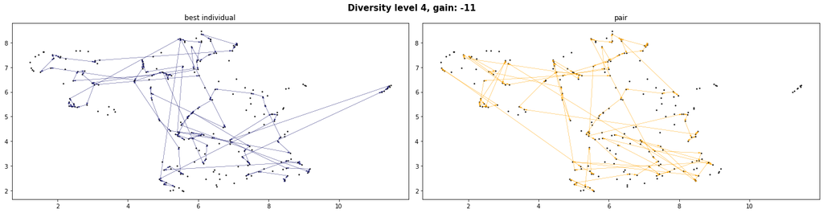

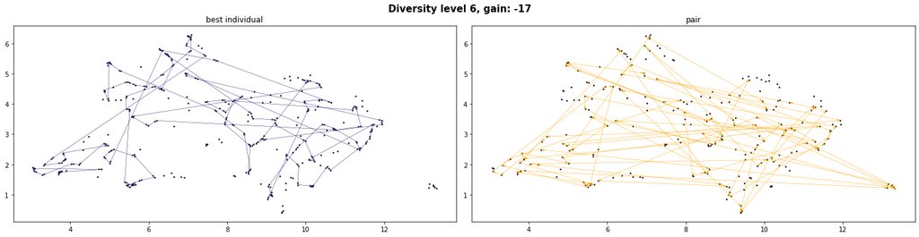

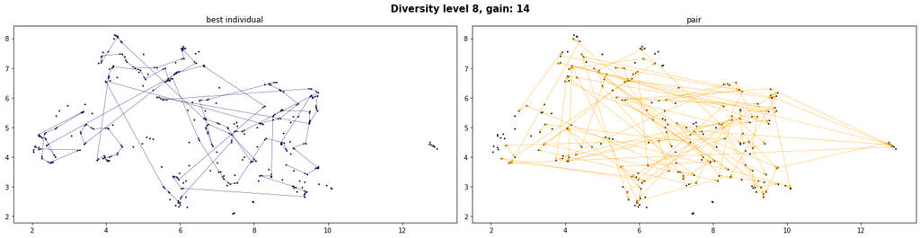

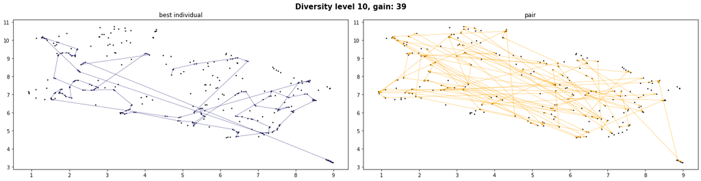

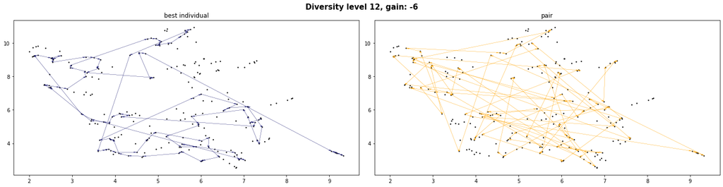

```python
for dl in levels:

    # Sample some trials
    subdata = data[(data['diversity_level']==dl) &\
                   (data['init_seed']=='goat') &\
                   (data['amount_gain'] > -20) &\ # filtering here to avoid extreme cases
                   (data['amount_gain'] < 100)] # filtering here to avoid extreme cases
    subdata = subdata.sample(n=1)#.sort_values('amount_gain')
    pairs = subdata.pair.tolist()
    agents = subdata.best_agent.tolist()
    gains = subdata.amount_gain.tolist()

    for idx, (pair, agent, gain) in enumerate(list(zip(pairs,
                                                       agents,
                                                       gains))):

        # Get and transform reference space
        space = pd.read_csv(f'{MODEL_PATH}/noised_vectors/{agent}.tsv',
                            sep='\t', index_col=0)
        animal_dict = dict(zip(space.index,
                           range(len(space.index))))
        scaled_space = StandardScaler().fit_transform(space)
        embedding = reducer.fit_transform(scaled_space)

        # Read in files and extract named animals
        idf = pd.read_csv(f'{LOG_PATH}/individual/{agent}_1_0.01179.txt')
        idf = idf[idf['init_seed']==seed]
        pdf = pd.read_csv(f'{LOG_PATH}/pairs/{pair}_2_0.01179.txt')
        pdf = pdf[pdf['init_seed']==seed]

        named_individual = idf.seed.tolist() + [idf.response.tolist()[-1]]
        named_idx_individual = [animal_dict[i] for i in named_individual]
        xs_individual = [embedding[n,0] for n in named_idx_individual]
        ys_individual = [embedding[n,1] for n in named_idx_individual]

        named_pair = pdf.seed.tolist() + [pdf.response.tolist()[-1]]
        named_idx_pair = [animal_dict[i] for i in named_pair]
        xs_pair = [embedding[n,0] for n in named_idx_pair]
        ys_pair = [embedding[n,1] for n in named_idx_pair]

        # Plot trial
        f, ax = plt.subplots(figsize=(20,5), ncols=2)
        ax[0].scatter(embedding[:,0], embedding[:,1], s=2, color='k')
        ax[1].scatter(embedding[:,0], embedding[:,1], s=2, color='k')
        for idx in range(len(xs_individual)-1):
            ax[0].arrow(x=xs_individual[idx],
                      y=ys_individual[idx],
                      dx=xs_individual[idx+1]-xs_individual[idx],
                      dy=ys_individual[idx+1]-ys_individual[idx],
                      shape='full',
                      lw=.2,
                      length_includes_head=True, head_width=.05,
                      color='midnightblue')
        for idx in range(len(xs_pair)-1):
            ax[1].arrow(x=xs_pair[idx],
                        y=ys_pair[idx],
                        dx=xs_pair[idx+1]-xs_pair[idx],
                        dy=ys_pair[idx+1]-ys_pair[idx],
                        shape='full',
                        lw=.2,
                        length_includes_head=True,
                        head_width=.05,
                        color='orange')
        ax[0].set_title('best individual')
        ax[1].set_title('pair')
        plt.suptitle(f'Diversity level {dl}, gain: {gain}',
                  fontsize=15,
                     weight='bold', y=1.02)
        plt.tight_layout()
        plt.show()
```

## Visualize number of dead-ends by diversity level

The plot below is a histogram of how often each word in space is the last named in a trial, across diversity levels. This gives an idea of how label swapping - used to generate diversity levels - increases the number of possible dead-ends in a pair. Low-diversity pairs will have roughly the same dead-end animals, but as diversity increases, both the semantics of the spece and dead ends will tend to differ within the pair - which increases chances of responses from one agent in a dense neighborhood unexpectedly leading the other agent to an isolated neighborhood and a dead end.

```python
animals = pd.read_csv(f'animal_game/models/animal_list.csv').rename({'Animals':
                                                                     'last_response_pair'},
                                                                      axis=1)
animals = concat_dfs([animals]*20)
animals['diversity_level'] = list(itertools.chain(*[[dl] * 240
                                                    for dl in range(0,20)]))
```

```python
nr_last = all_data.groupby(['diversity_level',
                            'last_response_pair'])['pair'].count().reset_index()
nr_last.rename({'pair': 'frequency'}, axis=1, inplace=True)
nr_last = nr_last.merge(animals, 'outer')
nr_last['frequency'] = nr_last['frequency'].fillna(0)
nr_last['log_frequency'] = np.where(nr_last['frequency']!=0,
                                    np.log10(nr_last['frequency']), 0)
```

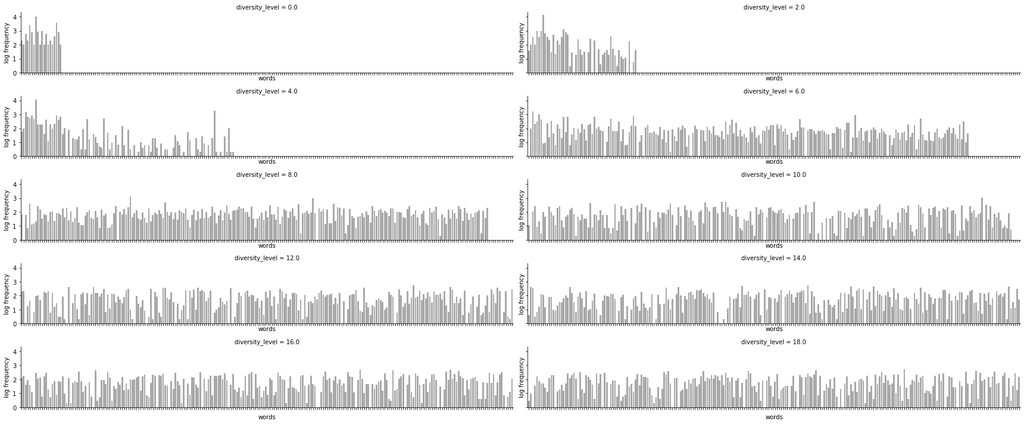

```python
f = sns.catplot(data=nr_last[nr_last['diversity_level'].isin(list(range(0,20,2)))],
                col='diversity_level',
                col_wrap=2,
                x='last_response_pair',
                y='log_frequency',
                height=2,
                aspect=6,
                facet_kws={'sharey': False},
                kind='bar',
                color='darkgrey')
for a in f.axes:
    a.set_xlabel('words')
    a.set_ylabel('log frequency')
f.set(xticklabels=[])
plt.tight_layout()
plt.show()
```